# puberty_cca

Theresa Cheng

3/29/2019

```
## Skim summary statistics
##  n obs: 174
##  n variables: 6
##
## ── Variable type:numeric ───────────────────────────────────────────────────────────────────────────────────────────────────
##          variable missing complete   n mean    sd   p0  p25  p50  p75 p100
##    hair_DHEA_pgmg       0      174 174 2.78 0.5   1.76 2.45 2.74 3.11 4.36
##     hair_EST_pgug       0      174 174 3.7  0.34  2.59 3.46 3.69 3.93 4.81
##    hair_TEST_pgmg       0      174 174 1.7  0.19  1.17 1.6  1.67 1.75 2.59
##  mean_saliva_DHEA       0      174 174 4.19 0.96  1.74 3.58 4.22 4.9  6.91
##   mean_saliva_EST       0      174 174 1.59 0.088 1.41 1.53 1.57 1.63 1.87
##  mean_saliva_TEST       0      174 174 3.67 0.41  2.71 3.35 3.68 3.94 5.01
##      hist
##  ▂▃▇▆▅▃▁▁
##  ▁▁▅▇▇▅▁▁
##  ▁▁▇▃▁▁▁▁
##  ▁▂▅▇▇▅▁▁
##  ▂▅▇▇▂▂▁▁
##  ▁▅▇▆▇▂▁▁
```

```
## Skim summary statistics
##  n obs: 174
##  n variables: 6
##
## ── Variable type:integer ───────────────────────────────────────────────────────────────────────────────────────────────────
##          variable missing complete   n mean   sd p0 p25 p50 p75 p100
##     pbip1_breasts       0      174 174 2.87 0.94  1   2   3   3    5
##  pbip2_pubic_hair       0      174 174 2.86 1.15  1   2   3   4    5
##       pds1_height       0      174 174 2.47 0.84  1   2   3   3    4
##         pds2_hair       0      174 174 2.43 0.85  1   2   2   3    4
##         pds3_skin       0      174 174 2.28 0.86  1   2   2   3    4
##      pds4_breasts       0      174 174 2.49 0.67  1   2   3   3    4
##      hist
##  ▂▅▁▇▁▃▁▁
##  ▃▇▁▇▁▇▁▂
##  ▂▁▅▁▁▇▁▁
##  ▃▁▇▁▁▇▁▂
##  ▅▁▇▁▁▇▁▁
##  ▁▁▇▁▁▇▁▁
```

```
##
## Skim summary statistics
##
## ── Variable type:numeric ───────────────────────────────────────────────────────────────────────────────────────────────────
##          variable missing complete   n  mean  sd    p0   p25   p50   p75
##  puberty_EM$ageS2       0      174 174 11.63 0.8 10.03 10.92 11.74 12.26
##   p100     hist
##  13.17 ▃▅▃▅▇▇▅▂
```

Examining univariate descriptive statistics of our dataset verifies that there is no missing data due to EM imputation at a prior step. Transformed hormone distributions are approximately normal, and we should verify whether the lower and upper limits are within biologically plausible ranges (did not set bounds during imputation). Ignoring the middle column of the PDS data (because its responses have four levels rather than five), the physical maturation data is approximately normal as well. In contrast, the age distribution is fairly flat, verifying that we sampled fairly evenly across the age range.

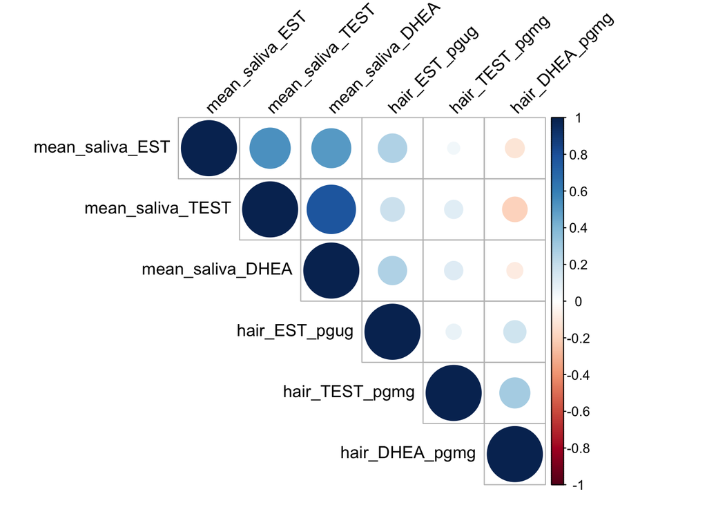

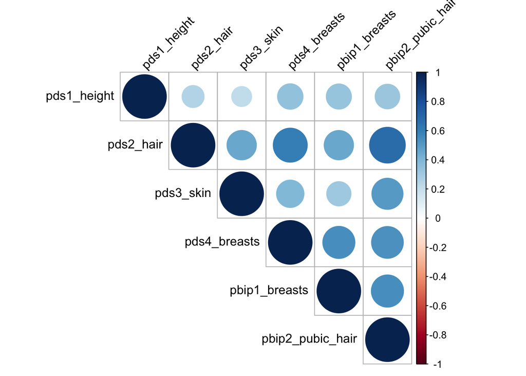

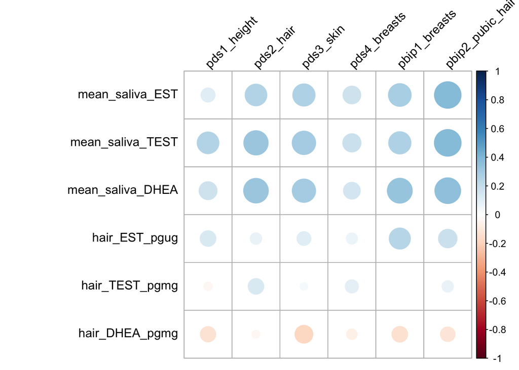

Examining correlation matrices suggests that the high correlations between the physical maturation measures (especially those between the PDS items related to hair growth and breast development, along with similar PBIP measures) might problematic in terms of collinearity. Additionally, the fairly low correlations between some of the hair hormone measures (especially the negative correlations with DHEA) may add noise to the model.

```r
# Modified from Dinga et al., 2018

select_and_cca_fit <- function(X, Y){
  #select
  correlations <- cor(Y, X, method = "spearman")
  correlations <- apply(correlations, 2, function(x){max(abs(x))})
  corr.threshold <- sort(correlations, decreasing = T)
  selected.X <- correlations >= corr.threshold
  selected.X <- X[,selected.X]
  #cca fit
  cca_model <- candisc::cancor(selected.X, Y)
  #return fitted model containing canonical correlations and wilks lambdas
  return(cca_model)
}

predict.cancor <- function(cancor.obj, X, Y){
  X_pred <- as.matrix(X) %*% cancor.obj$coef$X
  Y_pred <- as.matrix(Y) %*% cancor.obj$coef$Y
  XY_pred <- list(X_pred, Y_pred)
  names(XY_pred) <- c("X_pred", "Y_pred")
  return(XY_pred)
}

cca_cv <- function(hormone_variables, phys_mat_variables, age){
  n_folds <- 10
  folds <- createFolds(as.factor(age), n_folds, list=F)
  results_cancor <- list()

  for (fold in 1:n_folds) {

    # create training and test set
    train_hormones <- hormone_variables[folds != fold,]
    train_phys_mat <- phys_mat_variables[folds != fold,]
    test_hormones <- hormone_variables[folds == fold,]
    test_phys_mat <- phys_mat_variables[folds == fold,]

     # fit on training set
    cancor.fit <- select_and_cca_fit(train_hormones, train_phys_mat)

    # predict on test set
    XY_pred_cancor <- predict.cancor(cancor.fit,
                                     test_hormones[,cancor.fit$names$X],
                                     test_phys_mat)
    results_cancor[[fold]] <- diag(cor(XY_pred_cancor[[1]],
    XY_pred_cancor[[2]]))

  }
return(do.call(rbind, results_cancor))
}
```

```r
physical_mat_pds <- physical_mat[, c("pds1_height", "pds2_hair", "pds3_skin", "pds4_breasts" )]
physical_mat_pbip <- physical_mat[, c("pds1_height", "pbip2_pubic_hair", "pds3_skin", "pbip1_breasts")]

# run once with pds hair and breast measures
cca_model <- select_and_cca_fit(hormones, physical_mat)

cca_model$cancor
```

```
## [1] 0.50605437 0.25179991 0.21831703 0.10551991 0.08280497
```

```r
canonical.variates <- predict.cancor(cca_model,
  hormones[,cca_model$names$X],
  physical_mat)

cca_x_loadings <- cor(hormones, canonical.variates$X_pred)
cca_x_loadings
```

```
##                       Xcan1      Xcan2       Xcan3       Xcan4
## mean_saliva_EST  -0.5566202 -0.1006470  0.05333354 -0.08275822
## mean_saliva_TEST -0.8399719 -0.4292799  0.28496527 -0.08191418
## mean_saliva_DHEA -0.8687314 -0.2695708 -0.37174901 -0.10249898
## hair_EST_pgug    -0.4974866  0.4643619  0.02699752 -0.49458773
## hair_TEST_pgmg   -0.0177735 -0.6138493 -0.16049724  0.11246659
## hair_DHEA_pgmg    0.3674206 -0.3330417 -0.24840695 -0.80804512
##                         Xcan5
## mean_saliva_EST  -0.007421229
## mean_saliva_TEST -0.149167154
## mean_saliva_DHEA -0.154706097
## hair_EST_pgug     0.539934450
## hair_TEST_pgmg    0.764503165
## hair_DHEA_pgmg    0.198601138
```

```r
cca_y_loadings <- cor(physical_mat, canonical.variates$Y_pred)
cca_y_loadings
```

```
##                       Ycan1       Ycan2       Ycan3       Ycan4
## pds1_height      -0.5144442  0.04735434  0.62935877 -0.09840189
## pds2_hair        -0.6029073 -0.73057333 -0.20569281 -0.03163312
## pds3_skin        -0.6656526 -0.17065893  0.02404965  0.70461403
## pds4_breasts     -0.3544710 -0.31431629  0.12674292  0.30637609
## pbip1_breasts    -0.7587600  0.27490998 -0.30899087 -0.07562791
## pbip2_pubic_hair -0.8059338 -0.32780404  0.17938974 -0.11881781
##                        Ycan5
## pds1_height      -0.21820552
## pds2_hair         0.13280940
## pds3_skin        -0.09886443
## pds4_breasts      0.71178872
## pbip1_breasts     0.38933420
## pbip2_pubic_hair  0.34258291
```

```r
cor_matrix_pm
```

```
##                  pds1_height pds2_hair pds3_skin pds4_breasts
## pds1_height        1.0000000 0.2564819 0.2115249    0.3415912
## pds2_hair          0.2564819 1.0000000 0.4558210    0.6075916
## pds3_skin          0.2115249 0.4558210 1.0000000    0.3955224
## pds4_breasts       0.3415912 0.6075916 0.3955224    1.0000000
## pbip1_breasts      0.3338522 0.4536160 0.3115208    0.5413069
## pbip2_pubic_hair   0.3203184 0.6707395 0.5091475    0.5311432
##                  pbip1_breasts pbip2_pubic_hair
## pds1_height          0.3338522        0.3203184
## pds2_hair            0.4536160        0.6707395
## pds3_skin            0.3115208        0.5091475
## pds4_breasts         0.5413069        0.5311432
## pbip1_breasts        1.0000000        0.5445681
## pbip2_pubic_hair     0.5445681        1.0000000
```

Using all of the data, the canonical loadings of breast development onto the second variate are both positively and negatively associated with breast development. It seems likely that multicollinearity is an issue. We note particularly high correlations between pds2_hair and pbip2_pubic_hair, and pds4_breasts and pbip1_breasts. For now, we take the approach of running everything with PDS only, and then re-running with pbip in order to compare how using difference questionnaires for those two measures impacts the canonical loadings.

```r
# run once with pds hair and breast measures
cca_model_pds <- select_and_cca_fit(hormones, physical_mat_pds)

cca_model_pds$cancor
```

```
## [1] 0.42725861 0.18656750 0.10805372 0.08071286
```

```r
canonical.variates <- predict.cancor(cca_model_pds,
  hormones[,cca_model_pds$names$X],
  physical_mat_pds)

cca_x_loadings_pds <- cor(hormones, canonical.variates$X_pred)
cca_x_loadings_pds
```

```
##                       Xcan1        Xcan2       Xcan3       Xcan4
## mean_saliva_EST  -0.5441649 -0.008890592 -0.07930582  0.05320257
## mean_saliva_TEST -0.9419463  0.082814736 -0.31932549 -0.06253140
## mean_saliva_DHEA -0.8951778 -0.279946082  0.08792890  0.33549289
## hair_EST_pgug    -0.1913418 -0.201325208 -0.09718094  0.13422351
## hair_TEST_pgmg   -0.1504750 -0.715118588  0.04896859 -0.68085591
## hair_DHEA_pgmg    0.3341798 -0.714071199 -0.58329103  0.19544248
```

```r
cca_y_loadings_pds <- cor(physical_mat_pds, canonical.variates$Y_pred)
cca_y_loadings_pds
```

```
##                   Ycan1      Ycan2       Ycan3       Ycan4
## pds1_height  -0.5650968  0.6042155 -0.54521020 -0.13540708
## pds2_hair    -0.8037466 -0.5489663 -0.15143173 -0.17232451
## pds3_skin    -0.7846463  0.1669044  0.59558936 -0.04178923
## pds4_breasts -0.4466179 -0.1395864  0.02751238 -0.88334089
```

```r
par(mfrow=c(1,2))

plot(canonical.variates$X_pred[,1],
  canonical.variates$Y_pred[,1],
  bty='n',
  xlab='Hormone canonical variate 1',
  ylab='Physical mat pds canonical variate 1')
round(cca_model_pds$cancor[1], 2) # doesn't work, but r = .55
```

```
## [1] 0.43
```

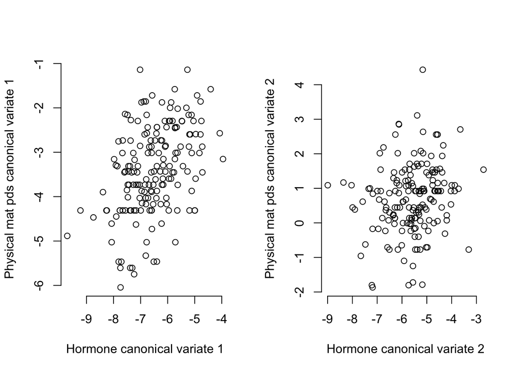

```r
plot(canonical.variates$X_pred[,2],
  canonical.variates$Y_pred[,2],
  bty='n',
  xlab='Hormone canonical variate 2',
  ylab='Physical mat pds canonical variate 2')
```

```r
round(cca_model_pds$cancor[2], 2) # doesn't work, but r = .35
```

```
## [1] 0.19
```

```r
real_model_pds <- cca_model_pds
real_results_cancor <- real_model_pds$cancor
real_results_wilks_pds <- Wilks(real_model_pds)
real_results_wilks_pds
```

```
##
## Test of H0: The canonical correlations in the
## current row and all that follow are zero
##
##      CanR LR test stat approx F numDF  denDF   Pr(> F)
## 1 0.42726      0.77470  2.76573    16 507.78 0.0002787 ***
## 2 0.18657      0.94771  1.00803     9 406.58 0.4327218
## 3 0.10805      0.98189  0.77129     4 336.00 0.5444967
## 4 0.08071      0.99349  1.10818     1 169.00 0.2939805
## ---
## Signif. codes:  0 '***' 0.001 '**' 0.01 '*' 0.05 '.' 0.1 ' ' 1
```

```r
### 10-fold cross-validation
pds_results_per_fold <- cca_cv(hormones, physical_mat_pds, puberty_EM$ageS2)[,1:2]
colMeans(pds_results_per_fold)
```

```
## [1]  0.31947059 -0.05446388
```

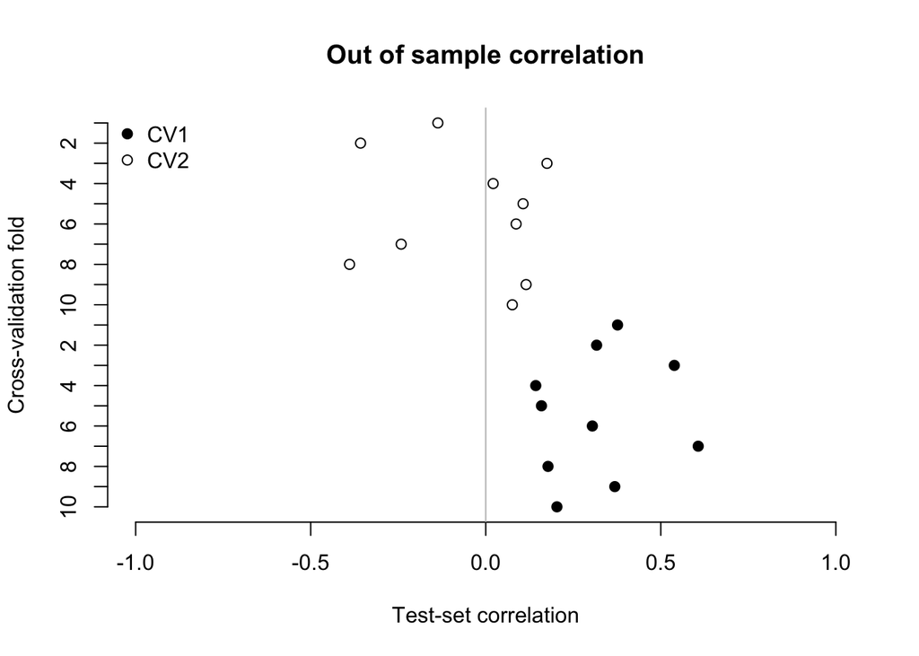

```r
par(mfrow=c(1,1))

plot(
  cbind(pds_results_per_fold[, 1], pds_results_per_fold[, 2]),
  1:20,
  yaxt = "n",
  xlim = c(-1, 1),
  bty = 'n',
  ylab = 'Cross-validation fold',
  xlab = 'Test-set correlation',
  main = 'Out of sample correlation',
  pch = c(rep(19, 10), rep(1, 10))
)
axis(2, at = c(1:20), labels = c(10:1, 10:1))#, lty='blank')
abline(v = 0, col = 'grey')
legend("topleft",
       c('CV1', 'CV2'),
       bty = 'n',
       pch = c(19, 1))
```

The first canonical variate seems to explain significant variation in the data, but none of the others. Examining both the x and y loadings suggests that this is a general puberty factor.

```r
# run once with pbip hair and breast measures
cca_model_pbip <- select_and_cca_fit(hormones, physical_mat[, c("pds1_height", "pbip2_pubic_hair", "pds3_skin", "pbip1_breasts" )])

cca_model_pbip$cancor
```

```
## [1] 0.48571858 0.21282163 0.10053933 0.09664613
```

```r
canonical.variates <- predict.cancor(cca_model_pbip,
  hormones[,cca_model_pbip$names$X],
  physical_mat_pbip)

cca_x_loadings_pbip <- cor(hormones, canonical.variates$X_pred)
cca_x_loadings_pbip
```

```
##                        Xcan1       Xcan2       Xcan3       Xcan4
## mean_saliva_EST  -0.55940295  0.07762765 0.073307108 -0.07309686
## mean_saliva_TEST -0.85875839  0.44771881 0.006565931 -0.24907586
## mean_saliva_DHEA -0.84989307 -0.18268228 0.044380075 -0.49227976
## hair_EST_pgug    -0.49035292 -0.27190484 0.680155565  0.47223953
## hair_TEST_pgmg   -0.02189243  0.08939961 0.268813490 -0.19618002
## hair_DHEA_pgmg    0.38035294  0.03562176 0.821556137 -0.42321182
```

```r
cca_y_loadings_pbip <- cor(physical_mat_pbip, canonical.variates$Y_pred)
cca_y_loadings_pbip
```

```
##                       Ycan1       Ycan2       Ycan3      Ycan4
## pds1_height      -0.5496252  0.45964784 -0.02893033  0.6969929
## pbip2_pubic_hair -0.8451426  0.25056933  0.26568468 -0.3903340
## pds3_skin        -0.6952847  0.02125857 -0.66700078 -0.2669030
## pbip1_breasts    -0.7800038 -0.54375719  0.25376207  0.1775584
```

```r
par(mfrow=c(1,2))

plot(canonical.variates$X_pred[,1],
  canonical.variates$Y_pred[,1],
  bty='n',
  xlab='Hormone canonical variate 1',
  ylab='Physical mat pbip canonical variate 1')
round(cca_model_pbip$cancor[1], 2)
```

```
## [1] 0.49
```

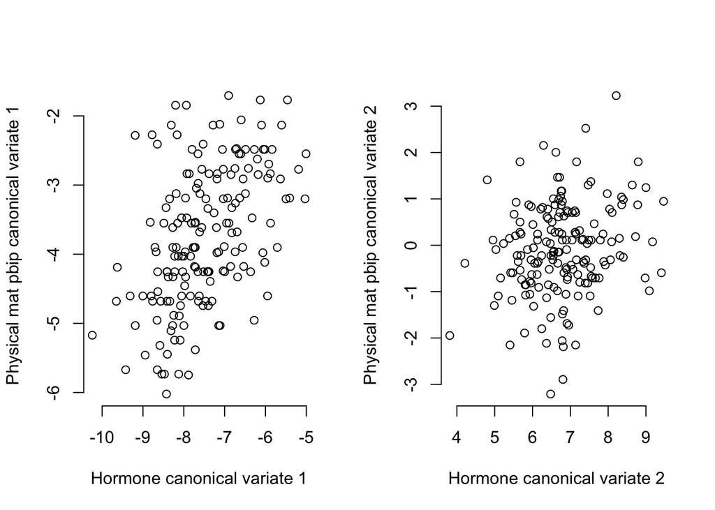

```r
plot(canonical.variates$X_pred[,2],
  canonical.variates$Y_pred[,2],
  bty='n',
  xlab='Hormone canonical variate 2',
  ylab='Physical mat pbip canonical variate 2')
```

```r
round(cca_model_pbip$cancor[2], 2)
```

```
## [1] 0.21
```

```r
real_model <- cca_model_pbip
real_results_cancor <- real_model$cancor
real_results_wilks_pbip <- Wilks(real_model)
real_results_wilks_pbip
```

```
##
## Test of H0: The canonical correlations in the
## current row and all that follow are zero
##
##      CanR LR test stat approx F numDF  denDF   Pr(> F)
## 1 0.48572      0.71535   3.6777    16 507.78 2.062e-06 ***
## 2 0.21282      0.93623   1.2399     9 406.58    0.2687
## 3 0.10054      0.98065   0.8249     4 336.00    0.5100
## 4 0.09665      0.99066   1.5934     1 169.00    0.2086
## ---
## Signif. codes:  0 '***' 0.001 '**' 0.01 '*' 0.05 '.' 0.1 ' ' 1
```

```r
pbip_results_per_fold <- cca_cv(hormones, physical_mat_pbip, puberty_EM$ageS2)[,1:2]
colMeans(pbip_results_per_fold)
```

```
## [1]  0.37905163 -0.05034401
```

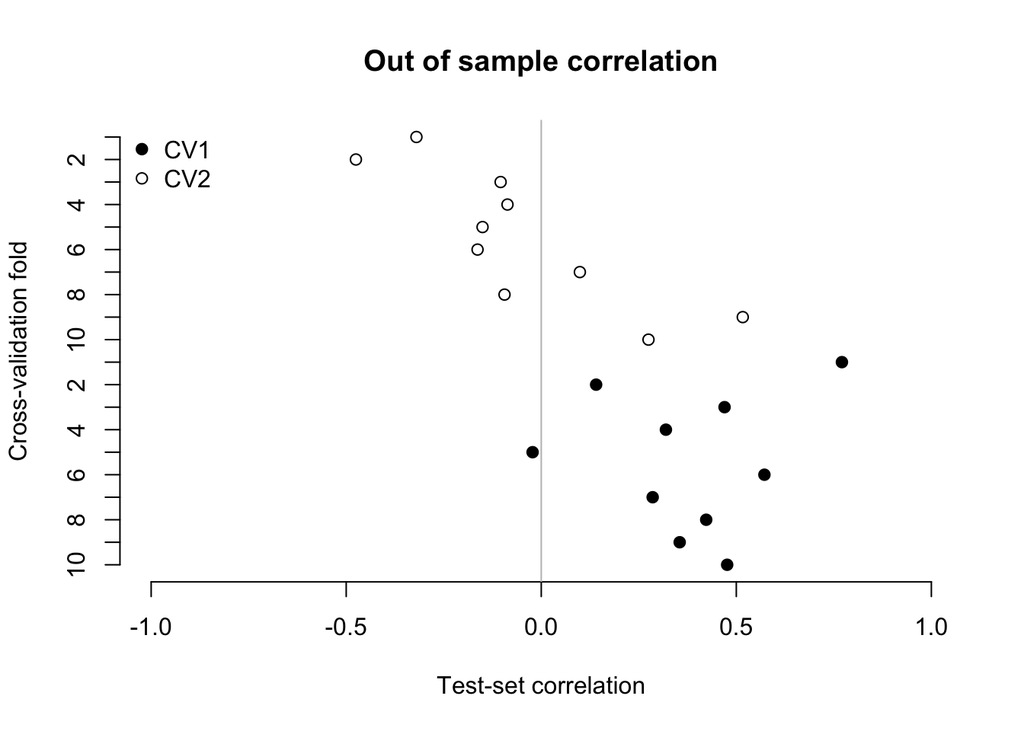

```r
par(mfrow=c(1,1))
plot(
  cbind(pbip_results_per_fold[, 1], pbip_results_per_fold[, 2]),
  1:20,
  yaxt = "n",
  xlim = c(-1, 1),
  bty = 'n',
  ylab = 'Cross-validation fold',
  xlab = 'Test-set correlation',
  main = 'Out of sample correlation',
  pch = c(rep(19, 10), rep(1, 10))
)
axis(2, at = c(1:20), labels = c(10:1, 10:1))#, lty='blank')
abline(v = 0, col = 'grey')
legend("topleft",
       c('CV1', 'CV2'),
       bty = 'n',
       pch = c(19, 1))
```

#### Possible next steps to discuss at lab meeting:

- Run reduced hormone models, as in CFA (removing hair DHEA and hair T).
- Search for penalized CCA options to be able to run with PBIP and PDS in the same model.
- Implement CCA with ordinal PBIP and PDS using the homals package.